# Valoración de opciones americanas mediante métodos numéricos

**Trabajo de Fin de Grado — Curso 2025-2026**

## Objetivo del notebook

En este notebook se implementan y comparan tres métodos numéricos para aproximar el precio de una opción americana:

1. Árbol binomial (modelo CRR de Cox, Ross y Rubinstein)
2. Diferencias finitas (esquema Crank-Nicolson sobre la EDP de Black-Scholes)
3. Simulación de Monte Carlo (algoritmo LSM de Longstaff y Schwartz)

A diferencia de las opciones europeas, las americanas no disponen de una fórmula cerrada para su valoración. La posibilidad de ejercicio anticipado obliga a recurrir a aproximaciones numéricas. Lo que interesa aquí no es solo obtener un precio, sino estudiar cómo se comporta cada método en términos de convergencia, estabilidad, velocidad y sensibilidad.

El desarrollo se organiza por bloques. Cada método se implementa, se prueba y se visualiza por separado. Al final se comparan los tres y se extraen conclusiones. Todo el código validado aquí se trasladará después a una aplicación interactiva en Streamlit.

## 1. Importación de librerías

Se cargan las librerías necesarias para el desarrollo del proyecto. Todas son paquetes estándar de cálculo numérico y visualización en Python. No se utiliza ninguna librería externa de valoración financiera; los tres métodos se programan desde cero.

```python
# Cálculo numérico
import numpy as np
from scipy.stats import norm
from scipy import linalg

# Gráficas
import matplotlib.pyplot as plt

# Medición de tiempos
import time

# Configuración general de las gráficas para que se vean bien en el notebook
plt.rcParams.update({
    'figure.figsize': (10, 6),
    'axes.grid': True,
    'grid.alpha': 0.3,
    'font.size': 11,
})

print("Librerías cargadas correctamente.")
```

```
Librerías cargadas correctamente.
```

## 2. Parámetros base (caso de referencia)

Se define un conjunto de parámetros que se va a reutilizar como caso de prueba a lo largo de todo el notebook. Se ha elegido una put americana ATM (at-the-money, es decir, con el precio del subyacente igual al strike). Este es el caso más interesante porque es donde la prima de ejercicio anticipado resulta más visible: al titular de una put le puede compensar ejercer antes del vencimiento si el subyacente baja lo suficiente.

Estos valores se pueden modificar en cualquier momento para explorar otros escenarios.

```python
# ============================================================
# Parámetros del caso de referencia
# ============================================================

S0 = 100        # Precio actual del activo subyacente
K = 100          # Precio de ejercicio (strike)
T = 1.0          # Tiempo hasta vencimiento (en años)
r = 0.05         # Tasa de interés libre de riesgo (anual, continua)
sigma = 0.20     # Volatilidad anualizada del subyacente
tipo = 'put'     # Tipo de opción: 'call' o 'put'

# Comprobar si la opción está ATM, ITM o OTM
if S0 == K:
    estado = 'ATM (at-the-money)'
elif (tipo == 'put' and S0 < K) or (tipo == 'call' and S0 > K):
    estado = 'ITM (in-the-money)'
else:
    estado = 'OTM (out-of-the-money)'

print("Caso de referencia:")
print(f"  S0    = {S0}")
print(f"  K     = {K}")
print(f"  T     = {T} año")
print(f"  r     = {r}")
print(f"  sigma = {sigma}")
print(f"  Tipo  : {tipo}")
print(f"  Estado: {estado}")
```

```
Caso de referencia:
  S0    = 100
  K     = 100
  T     = 1.0 año
  r     = 0.05
  sigma = 0.2
  Tipo  : put
  Estado: ATM (at-the-money)
```

## 3. Método binomial (CRR)

### Idea del método

El modelo binomial divide el tiempo hasta el vencimiento en N pasos de tamaño Δt = T/N. En cada paso, el precio del activo puede subir (se multiplica por u) o bajar (se multiplica por d). Esto genera un árbol de precios posibles.

Los factores de subida y bajada se calculan a partir de la volatilidad:

$$u = e^{\sigma \sqrt{\Delta t}}, \quad d = \frac{1}{u}$$

Para que no existan oportunidades de arbitraje, se define una probabilidad neutral al riesgo:

$$p = \frac{e^{r \Delta t} - d}{u - d}$$

El precio de la opción se calcula hacia atrás, desde el vencimiento hasta el instante inicial. En cada nodo se compara el valor de esperar (continuación) con el valor de ejercer en ese momento, y se toma el mayor de los dos:

$$V_{i,j} = \max\Big(\text{payoff}(S_{i,j}),\; e^{-r \Delta t} \big[ p \cdot V_{i+1,j+1} + (1-p) \cdot V_{i+1,j} \big] \Big)$$

Esa comparación en cada nodo es lo que distingue a la opción americana de la europea. En una europea simplemente se toma el valor de continuación sin comparar.

```python
def precio_binomial(S0, K, T, r, sigma, tipo='put', N=100):
    """
    Calcula el precio de una opción americana con el modelo binomial CRR.

    Parámetros
    ----------
    S0    : float - Precio actual del subyacente
    K     : float - Precio de ejercicio
    T     : float - Tiempo al vencimiento (años)
    r     : float - Tasa libre de riesgo
    sigma : float - Volatilidad
    tipo  : str   - 'call' o 'put'
    N     : int   - Número de pasos del árbol

    Retorna
    -------
    precio : float - Valor de la opción americana
    """
    dt = T / N
    u = np.exp(sigma * np.sqrt(dt))
    d = 1.0 / u
    p = (np.exp(r * dt) - d) / (u - d)
    descuento = np.exp(-r * dt)

    # Precios del subyacente en el último paso (vencimiento).
    # En el nodo j del paso N, el precio es S0 * u^(N-j) * d^j.
    precios_final = np.array([S0 * u**(N - j) * d**j for j in range(N + 1)])

    # Payoff en el vencimiento
    if tipo == 'call':
        valores = np.maximum(precios_final - K, 0.0)
    else:
        valores = np.maximum(K - precios_final, 0.0)

    # Inducción hacia atrás: se recorre el árbol desde el paso N-1
    # hasta el paso 0. En cada nodo se calcula el valor de continuación
    # (esperar) y se compara con el payoff de ejercer en ese instante.
    for i in range(N - 1, -1, -1):
        precios_i = np.array([S0 * u**(i - j) * d**j for j in range(i + 1)])

        # Valor de continuación: promedio ponderado descontado
        continuacion = descuento * (p * valores[:i+1] + (1 - p) * valores[1:i+2])

        # Payoff si se ejerce ahora
        if tipo == 'call':
            ejercicio = np.maximum(precios_i - K, 0.0)
        else:
            ejercicio = np.maximum(K - precios_i, 0.0)

        # Opción americana: vale el máximo entre ejercer y esperar
        valores = np.maximum(continuacion, ejercicio)

    return float(valores[0])

print("Función precio_binomial() definida.")
```

```
Función precio_binomial() definida.
```

### Precio europeo de referencia (Black-Scholes)

Para saber si el método binomial está dando resultados razonables, conviene tener un valor de referencia. La opción europea sí tiene fórmula cerrada (Black-Scholes), así que se puede calcular de forma exacta.

La opción americana siempre vale igual o más que la europea (porque ofrece más derechos), así que el precio europeo sirve como cota inferior. La diferencia entre ambos precios es la prima de ejercicio anticipado.

```python
def precio_bs_europeo(S0, K, T, r, sigma, tipo='put'):
    """
    Precio de una opción europea con la fórmula cerrada de Black-Scholes.
    Se usa como referencia para comparar con los métodos numéricos.

    Parámetros
    ----------
    S0    : float - Precio actual del subyacente
    K     : float - Precio de ejercicio
    T     : float - Tiempo al vencimiento (años)
    r     : float - Tasa libre de riesgo
    sigma : float - Volatilidad
    tipo  : str   - 'call' o 'put'

    Retorna
    -------
    precio : float - Valor de la opción europea
    """
    d1 = (np.log(S0 / K) + (r + 0.5 * sigma**2) * T) / (sigma * np.sqrt(T))
    d2 = d1 - sigma * np.sqrt(T)

    if tipo == 'call':
        precio = S0 * norm.cdf(d1) - K * np.exp(-r * T) * norm.cdf(d2)
    else:
        precio = K * np.exp(-r * T) * norm.cdf(-d2) - S0 * norm.cdf(-d1)

    return precio

print("Función precio_bs_europeo() definida.")
```

```
Función precio_bs_europeo() definida.
```

### Primera prueba del método binomial

Se calcula el precio de la put americana con los parámetros base, usando distintos valores de N (número de pasos del árbol). El objetivo es doble:

- Comprobar que el precio se estabiliza al aumentar N.
- Verificar que la opción americana vale más que la europea (la diferencia es la prima de ejercicio anticipado).

```python
# Precio de referencia: Black-Scholes europeo
precio_europeo = precio_bs_europeo(S0, K, T, r, sigma, tipo)
print(f"Precio Black-Scholes europeo ({tipo}): {precio_europeo:.6f}")
print()

# Prueba del binomial con distintos números de pasos
pasos_prueba = [10, 25, 50, 100, 200, 500]

print(f"{'N':>6}  {'Precio':>12}  {'Tiempo (ms)':>12}")
print("-" * 36)

for N in pasos_prueba:
    t0 = time.perf_counter()
    precio = precio_binomial(S0, K, T, r, sigma, tipo, N)
    ms = (time.perf_counter() - t0) * 1000
    print(f"{N:>6}  {precio:>12.6f}  {ms:>12.2f}")

# Comparación con el europeo (usando el último valor calculado, N=500)
prima_anticipado = precio - precio_europeo
print()
print(f"Precio americana (N=500):  {precio:.6f}")
print(f"Precio europea (B-S):      {precio_europeo:.6f}")
print(f"Prima ejercicio anticipado: {prima_anticipado:.6f}")
```

```
Precio Black-Scholes europeo (put): 5.573526

     N        Precio   Tiempo (ms)
------------------------------------
    10      6.004259          0.25
    25      6.146185          0.42
    50      6.073728          0.76
   100      6.082354          1.61
   200      6.086383          4.05
   500      6.088810         24.61

Precio americana (N=500):  6.088810
Precio europea (B-S):      5.573526
Prima ejercicio anticipado: 0.515284
```

### Convergencia del método binomial

Se representa gráficamente cómo evoluciona el precio de la opción americana al aumentar el número de pasos N. Si el método funciona bien, la curva debería estabilizarse a partir de cierto punto. También se dibuja el precio europeo de Black-Scholes como referencia.

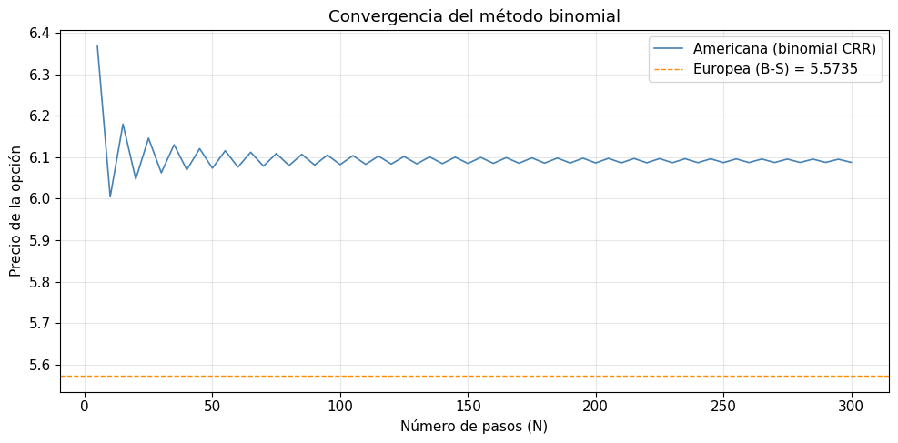

```
Con N=300, el precio binomial es: 6.087723
```

```python
# Rango de valores de N para el estudio de convergencia
valores_N = list(range(5, 305, 5))

# Calcular el precio binomial para cada N
precios_bin = [precio_binomial(S0, K, T, r, sigma, tipo, n) for n in valores_N]

# Precio europeo (referencia constante)
precio_eu = precio_bs_europeo(S0, K, T, r, sigma, tipo)

# Gráfica
plt.figure(figsize=(10, 5))
plt.plot(valores_N, precios_bin, color='steelblue', linewidth=1.2, label='Americana (binomial CRR)')
plt.axhline(precio_eu, color='darkorange', linestyle='--', linewidth=1.0, label=f'Europea (B-S) = {precio_eu:.4f}')
plt.xlabel('Número de pasos (N)')
plt.ylabel('Precio de la opción')
plt.title('Convergencia del método binomial')
plt.legend()
plt.tight_layout()
plt.show()

print(f"Con N=300, el precio binomial es: {precios_bin[-1]:.6f}")
```

### Visualización del árbol binomial

Para entender qué está haciendo el método, resulta útil dibujar el árbol con pocos pasos. Se representa un árbol con N=5, mostrando los precios del subyacente en cada nodo. Las ramas hacia arriba corresponden al factor de subida u y las ramas hacia abajo al factor de bajada d.

Con N grande el árbol se vuelve imposible de dibujar, pero con N pequeño se puede ver la estructura y comprobar que los precios encajan.

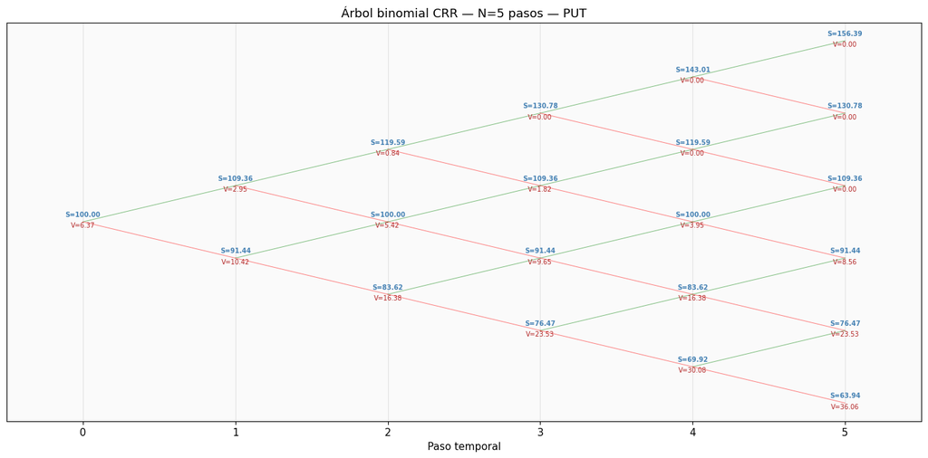

```
Precio de la opción (nodo raíz): 6.367830
Factores: u = 1.093565, d = 0.914441, p = 0.533762
```

```python
def dibujar_arbol_binomial(S0, K, T, r, sigma, tipo='put', N=5):
    """
    Dibuja el árbol binomial con N pasos, mostrando el precio del
    subyacente y el valor de la opción en cada nodo.
    """
    dt = T / N
    u = np.exp(sigma * np.sqrt(dt))
    d = 1.0 / u
    p = (np.exp(r * dt) - d) / (u - d)
    descuento = np.exp(-r * dt)

    # Construir matrices de precios y valores
    precios = np.zeros((N + 1, N + 1))
    valores = np.zeros((N + 1, N + 1))

    # Rellenar precios en todos los nodos
    for i in range(N + 1):
        for j in range(i + 1):
            precios[j, i] = S0 * u**(i - j) * d**j

    # Payoff en el vencimiento
    for j in range(N + 1):
        if tipo == 'call':
            valores[j, N] = max(precios[j, N] - K, 0.0)
        else:
            valores[j, N] = max(K - precios[j, N], 0.0)

    # Inducción hacia atrás
    for i in range(N - 1, -1, -1):
        for j in range(i + 1):
            continuacion = descuento * (p * valores[j, i+1] + (1 - p) * valores[j+1, i+1])
            if tipo == 'call':
                ejercicio = max(precios[j, i] - K, 0.0)
            else:
                ejercicio = max(K - precios[j, i], 0.0)
            valores[j, i] = max(continuacion, ejercicio)

    # Dibujar el árbol
    fig, ax = plt.subplots(figsize=(14, 7))

    for i in range(N + 1):
        for j in range(i + 1):
            x = i
            y = i - 2 * j  # Posición vertical: arriba = subidas, abajo = bajadas

            # Texto: precio del subyacente y valor de la opción
            ax.text(x, y + 0.15, f'S={precios[j,i]:.2f}',
                    ha='center', fontsize=7, color='steelblue', fontweight='bold')
            ax.text(x, y - 0.15, f'V={valores[j,i]:.2f}',
                    ha='center', fontsize=7, color='firebrick')

            # Dibujar ramas hacia el siguiente paso
            if i < N:
                x2 = i + 1
                y_up = (i + 1) - 2 * j        # subida: mismo j
                y_dn = (i + 1) - 2 * (j + 1)  # bajada: j+1
                ax.plot([x, x2], [y, y_up], color='green', linewidth=0.7, alpha=0.5)
                ax.plot([x, x2], [y, y_dn], color='red', linewidth=0.7, alpha=0.5)

    ax.set_xlim(-0.5, N + 0.5)
    ax.set_title(f'Árbol binomial CRR — N={N} pasos — {tipo.upper()}', fontsize=13)
    ax.set_xlabel('Paso temporal')
    ax.set_yticks([])
    ax.set_facecolor('#fafafa')
    plt.tight_layout()
    plt.show()

    print(f"Precio de la opción (nodo raíz): {valores[0, 0]:.6f}")
    print(f"Factores: u = {u:.6f}, d = {d:.6f}, p = {p:.6f}")

# Dibujar con N=5
dibujar_arbol_binomial(S0, K, T, r, sigma, tipo, N=5)
```

```python
# Resumen del método binomial con los valores calculados
precio_bin_ref = precio_binomial(S0, K, T, r, sigma, tipo, N=500)
precio_eu_ref = precio_bs_europeo(S0, K, T, r, sigma, tipo)
prima_ea = precio_bin_ref - precio_eu_ref

# Medir el tiempo con N=500
t0 = time.perf_counter()
_ = precio_binomial(S0, K, T, r, sigma, tipo, N=500)
tiempo_ref = (time.perf_counter() - t0) * 1000

print("=" * 55)
print("   RESUMEN DEL MÉTODO BINOMIAL (CRR)")
print("=" * 55)
print()
print(f"  Precio americana (N=500):     {precio_bin_ref:.6f}")
print(f"  Precio europea (B-S):         {precio_eu_ref:.6f}")
print(f"  Prima ejercicio anticipado:   {prima_ea:.6f}")
print(f"  Tiempo de cálculo (N=500):    {tiempo_ref:.2f} ms")
print()
print("  Observaciones:")
print("  - El precio converge al aumentar N (estable a partir de N≈100)")
print("  - La americana vale más que la europea, como se esperaba")
print("  - El tiempo de cálculo es bajo, del orden de milisegundos")
print()
print("  Bloque listo. Siguiente paso: diferencias finitas.")
print("=" * 55)
```

```
=======================================================
   RESUMEN DEL MÉTODO BINOMIAL (CRR)
=======================================================

  Precio americana (N=500):     6.088810
  Precio europea (B-S):         5.573526
  Prima ejercicio anticipado:   0.515284
  Tiempo de cálculo (N=500):    24.59 ms

  Observaciones:
  - El precio converge al aumentar N (estable a partir de N≈100)
  - La americana vale más que la europea, como se esperaba
  - El tiempo de cálculo es bajo, del orden de milisegundos

  Bloque listo. Siguiente paso: diferencias finitas.
=======================================================
```

## 4. Método de diferencias finitas (Crank-Nicolson)

### Idea del método

El precio de una opción satisface la ecuación diferencial en derivadas parciales (EDP) de Black-Scholes:

$$\frac{\partial V}{\partial t} + \frac{1}{2}\sigma^2 S^2 \frac{\partial^2 V}{\partial S^2} + rS\frac{\partial V}{\partial S} - rV = 0$$

Para resolverla numéricamente, se discretiza el dominio en una malla: el eje horizontal es el precio del subyacente S (dividido en N_S nodos) y el eje temporal es t (dividido en N_T pasos). Se parte de la condición conocida en el vencimiento (el payoff) y se avanza hacia atrás en el tiempo.

El esquema Crank-Nicolson promedia las aproximaciones de las derivadas entre el instante actual y el siguiente, lo que le da una precisión de segundo orden tanto en tiempo como en espacio. Es un esquema implícito, así que en cada paso temporal hay que resolver un sistema de ecuaciones lineales (tridiagonal, lo cual es rápido).

Para la opción americana, después de resolver el sistema en cada paso, se impone que el valor de la opción nunca sea inferior al payoff de ejercicio inmediato. Esa imposición es la que recoge la posibilidad de ejercer antes del vencimiento.

```python
def precio_diferencias_finitas(S0, K, T, r, sigma, tipo='put', N_S=200, N_T=1000):
    """
    Calcula el precio de una opción americana mediante diferencias finitas
    con el esquema Crank-Nicolson.

    Parámetros
    ----------
    S0    : float - Precio actual del subyacente
    K     : float - Precio de ejercicio
    T     : float - Tiempo al vencimiento (años)
    r     : float - Tasa libre de riesgo
    sigma : float - Volatilidad
    tipo  : str   - 'call' o 'put'
    N_S   : int   - Número de nodos en la dimensión del precio
    N_T   : int   - Número de pasos temporales

    Retorna
    -------
    precio  : float    - Valor de la opción americana en S0
    S_grid  : np.array - Vector de precios del subyacente (malla)
    V_grid  : np.array - Vector de valores de la opción en t=0
    """
    # Definir la malla espacial: S va de 0 a S_max
    # S_max se pone suficientemente lejos para que no afecte al resultado
    S_max = 4.0 * K
    dS = S_max / N_S
    S = np.linspace(0, S_max, N_S + 1)
    dt = T / N_T

    # Condición terminal: payoff en el vencimiento (t = T)
    if tipo == 'call':
        V = np.maximum(S - K, 0.0)
    else:
        V = np.maximum(K - S, 0.0)

    # Índices de los nodos interiores (se excluyen los extremos S=0 y S=S_max
    # porque ahí se aplican condiciones de contorno)
    idx = np.arange(1, N_S)

    # Coeficientes del esquema Crank-Nicolson.
    # Vienen de discretizar los términos de la EDP de Black-Scholes.
    alpha = 0.5 * dt * (sigma**2 * idx**2 - r * idx)
    beta  = -dt * (sigma**2 * idx**2 + r)
    gamma = 0.5 * dt * (sigma**2 * idx**2 + r * idx)

    # Matrices tridiagonales del sistema Crank-Nicolson:
    #   A_izq * V^{n+1} = A_der * V^n
    # theta = 0.5 es lo que hace que sea Crank-Nicolson (promedio)
    theta = 0.5
    M = N_S - 1  # Tamaño del sistema (nodos interiores)

    # Matriz izquierda (A_izq): la que multiplica a la incógnita V^{n+1}
    diag_izq  = 1.0 - theta * beta
    sub_izq   = -theta * alpha[1:]      # subdiagonal
    super_izq = -theta * gamma[:-1]     # superdiagonal

    A_izq = (np.diag(diag_izq) +
             np.diag(sub_izq, -1) +
             np.diag(super_izq, 1))

    # Matriz derecha (A_der): la que multiplica al valor conocido V^n
    diag_der  = 1.0 + (1 - theta) * beta
    sub_der   = (1 - theta) * alpha[1:]
    super_der = (1 - theta) * gamma[:-1]

    A_der = (np.diag(diag_der) +
             np.diag(sub_der, -1) +
             np.diag(super_der, 1))

    # Factorización LU de la matriz izquierda (se hace una sola vez,
    # porque no cambia entre pasos temporales)
    lu, piv = linalg.lu_factor(A_izq)

    # Iteración hacia atrás en el tiempo
    for n in range(N_T):
        # Lado derecho del sistema: A_der * V_interiores
        rhs = A_der @ V[1:N_S]

        # Condiciones de contorno (valores en los extremos de la malla)
        if tipo == 'call':
            bc_izq = 0.0
            bc_der = S_max - K * np.exp(-r * (T - (n + 1) * dt))
        else:
            bc_izq = K * np.exp(-r * (T - (n + 1) * dt))
            bc_der = 0.0

        # Incorporar las condiciones de contorno al sistema
        rhs[0]  += theta * alpha[0] * bc_izq + (1 - theta) * alpha[0] * V[0]
        rhs[-1] += theta * gamma[-1] * bc_der + (1 - theta) * gamma[-1] * V[N_S]

        # Resolver el sistema tridiagonal
        V_nuevo = linalg.lu_solve((lu, piv), rhs)

        # Condición de ejercicio anticipado (opción americana):
        # el valor nunca puede ser menor que el payoff inmediato
        if tipo == 'call':
            intrinseco = np.maximum(S[1:N_S] - K, 0.0)
        else:
            intrinseco = np.maximum(K - S[1:N_S], 0.0)

        V_nuevo = np.maximum(V_nuevo, intrinseco)

        # Actualizar el vector de valores
        V[0]      = bc_izq
        V[N_S]    = bc_der
        V[1:N_S]  = V_nuevo

    # Interpolar el precio en S0 (porque S0 puede no coincidir
    # exactamente con un nodo de la malla)
    precio = np.interp(S0, S, V)

    return precio, S, V

print("Función precio_diferencias_finitas() definida.")
```

```
Función precio_diferencias_finitas() definida.
```

### Prueba del método de diferencias finitas

Se calcula el precio de la put americana con los parámetros base, usando distintas resoluciones de malla. Se varía tanto el número de nodos espaciales (N_S) como los pasos temporales (N_T). El precio debe estabilizarse al refinar la malla y coincidir aproximadamente con el valor obtenido con el binomial.

```python
# Prueba con distintas resoluciones de malla
configuraciones = [
    (50,  200),
    (100, 400),
    (200, 800),
    (200, 1500),
    (400, 2000),
]

print(f"{'N_S':>6}  {'N_T':>6}  {'Precio':>12}  {'Tiempo (ms)':>12}")
print("-" * 42)

for N_S, N_T in configuraciones:
    t0 = time.perf_counter()
    precio_fd, _, _ = precio_diferencias_finitas(S0, K, T, r, sigma, tipo, N_S, N_T)
    ms = (time.perf_counter() - t0) * 1000
    print(f"{N_S:>6}  {N_T:>6}  {precio_fd:>12.6f}  {ms:>12.2f}")

# Comparación con los otros valores conocidos
print()
print(f"Referencia binomial (N=500):   {precio_bin_ref:.6f}")
print(f"Referencia europea (B-S):      {precio_eu_ref:.6f}")
print(f"Diferencia con binomial:       {abs(precio_fd - precio_bin_ref):.6f}")
```

```
   N_S     N_T        Precio   Tiempo (ms)
------------------------------------------
    50     200      6.197914          6.30
   100     400      6.042926          7.16
   200     800      6.078416         19.01
   200    1500      6.078714         31.58
   400    2000      6.087223        627.57

Referencia binomial (N=500):   6.088810
Referencia europea (B-S):      5.573526
Diferencia con binomial:       0.001587
```

### Perfil de valor de la opción

Se representa el valor de la opción en t=0 en función del precio del subyacente S. Esto es el resultado directo de la malla de diferencias finitas: para cada punto de la malla se obtiene un valor V(S).

Se dibuja también el valor intrínseco (payoff de ejercicio inmediato) como referencia. La diferencia entre la curva de la opción y el valor intrínseco es el valor temporal: lo que se paga de más por la posibilidad de que el mercado se mueva a favor.

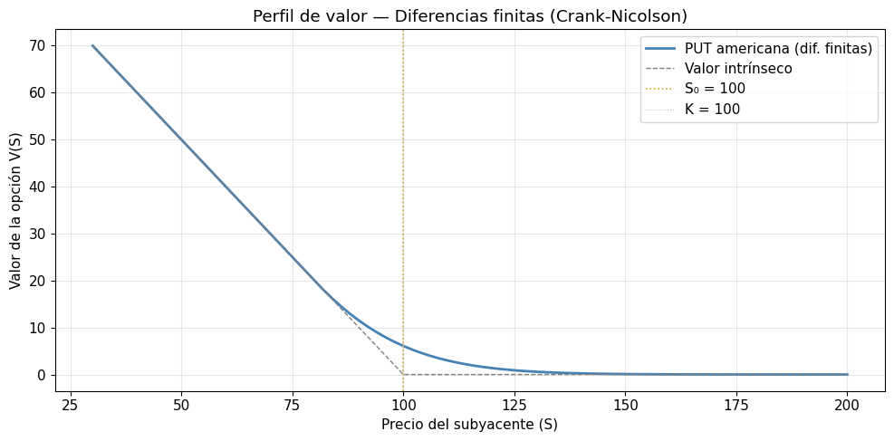

```python
# Calcular el perfil con una malla razonable
_, S_grid, V_grid = precio_diferencias_finitas(S0, K, T, r, sigma, tipo, N_S=200, N_T=800)

# Valor intrínseco (payoff si se ejerce ahora mismo)
if tipo == 'call':
    intrinseco = np.maximum(S_grid - K, 0.0)
else:
    intrinseco = np.maximum(K - S_grid, 0.0)

# Zona de visualización centrada alrededor del strike
mascara = (S_grid >= K * 0.3) & (S_grid <= K * 2.0)

plt.figure(figsize=(10, 5))
plt.plot(S_grid[mascara], V_grid[mascara], color='steelblue', linewidth=2.0,
         label=f'{tipo.upper()} americana (dif. finitas)')
plt.plot(S_grid[mascara], intrinseco[mascara], color='gray', linewidth=1.0,
         linestyle='--', label='Valor intrínseco')
plt.axvline(S0, color='goldenrod', linewidth=1.2, linestyle=':', label=f'S₀ = {S0}')
plt.axvline(K, color='silver', linewidth=0.8, linestyle=':', label=f'K = {K}')
plt.xlabel('Precio del subyacente (S)')
plt.ylabel('Valor de la opción V(S)')
plt.title('Perfil de valor — Diferencias finitas (Crank-Nicolson)')
plt.legend()
plt.tight_layout()
plt.show()
```